# Spotify Assessment: Warmup

James Kelleher

The purpose of this analysis is to explore whether or not there is a signifant difference between male and female listeners with regards to total listening time. The required data is provided in the `data_sample` folder. We will load the the data into data tables using the `fread` function due to the rapid performance of `fread` and data tables.

```r
library(data.table)
library(ggplot2)

user.data <- fread("data_sample/user_data_sample.csv", na.strings = c("unknown", ""))
end.song.data <- fread("data_sample/end_song_sample.csv", na.strings = c("unknown", ""))
```

Once we have the data loaded, we want to group the end song data by user ID in order to find the sum of the time spent playing.

```r
total.time.spent.listening <- end.song.data[, list(time_played_ms = sum(ms_played)), by = user_id]
```

We can merge the info on each user’s gender into the table on each user’s total time spent listening on the user ID.

```r
total.time.spent.listening <- merge(x = total.time.spent.listening, y = user.data[, list(gender, user_id)],
                                    by = "user_id", all.x = TRUE)  # acts as left join

# clear any rows with missing values
total.time.spent.listening <- total.time.spent.listening[complete.cases(total.time.spent.listening), ]
```

One quick and simple way to determine whether male and female listeners are significantly different in their overall listening is to compare histograms.

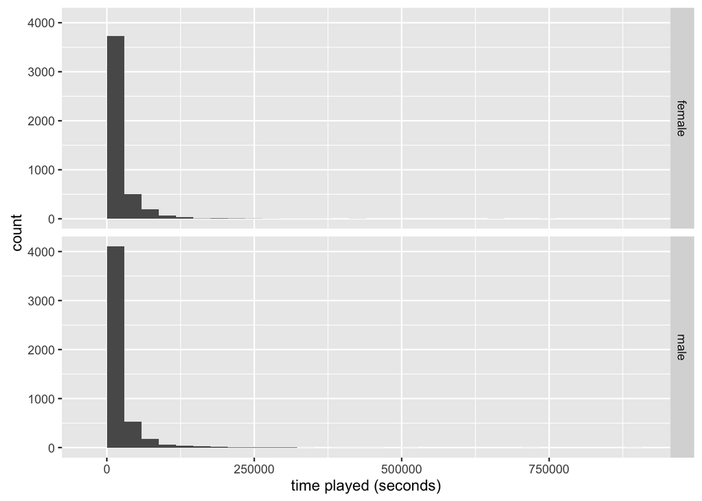

```r
# we convert time_played_ms to seconds in order to make it easier to understand the plot
qplot(time_played_ms / 1000, data = total.time.spent.listening, geom = "histogram", facets = (gender ~ .),
      bins = 30, xlab = "time played (seconds)")
```

```r
cutoff_ms <- 100000000
cutoff_sec <- cutoff_ms / 1000
```

It’s clear from the plot that the vast majority of listeners have committed less than 100000 seconds. In fact, only 2.53% of listeners have logged more time. We can obtain a more descriptive image of the data by focusing on the values within that cutoff.

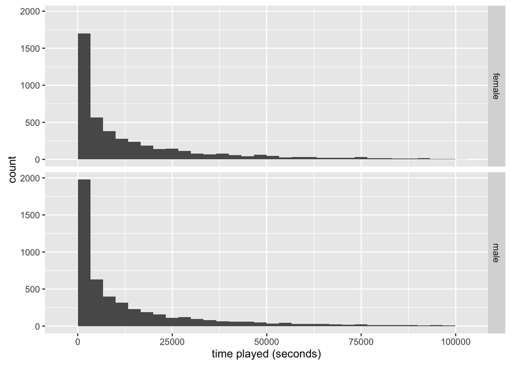

```r
in_cutoff <- total.time.spent.listening$time_played_ms < cutoff_ms
qplot(time_played_ms / 1000, data = total.time.spent.listening[in_cutoff], geom = "histogram",
      facets = (gender ~ .), bins = 30, xlab = "time played (seconds)")
```

[^1]: Note that with 30 bins and a maximum value of 100,000 seconds, Each bin incorportates a range of 3333.33 seconds. This is equal to about 0.93 hours.